# Project_1 Urban Ministries Durham

Wenwen Mei

9/25/2019

## Goals:

- Examine the growth of UMD from 1999-2018
- Explore the relationship between services and the month of the year
  - Bus tickets
  - Food Products
  - Hygiene products

###### Note: All the analyses are conducted from 1999-2018

## Growth of UMD From 1999-2018

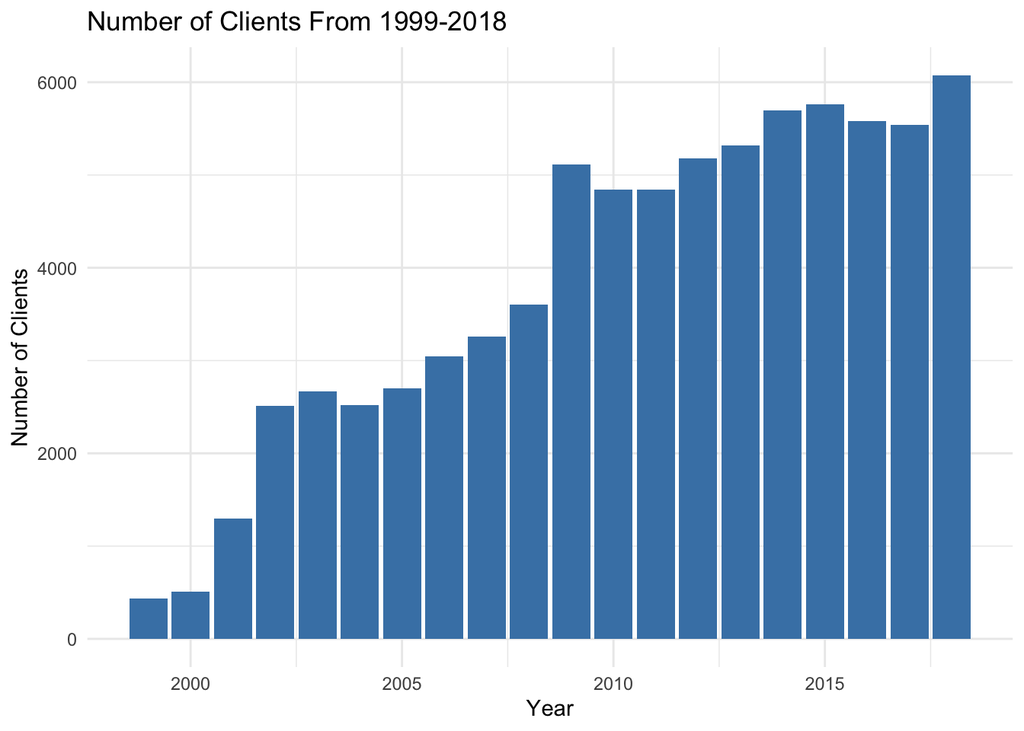

##### This plot suggests UMD has been growing since 1999. In 1999, UMD served approximately 500 people. In 2018, UMD seved over 6,000 people. This is a large increase in the number of residents they have been serving in the last 20 years. Please note that the number of clients per year includes both new clients and old clients.

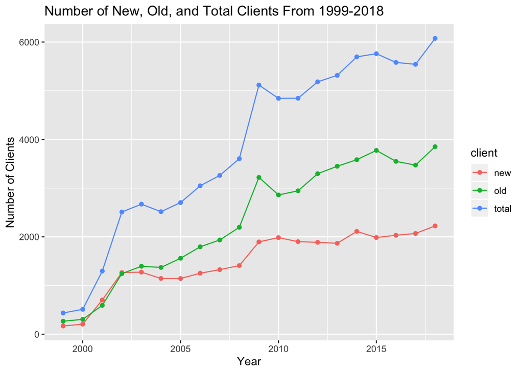

##### Here is a plot that breaks the previous plot down by the number of new clients, returners, and the total number of clients per years. The pattern for the total number of clients is comparably more dependent on the pattern of the number of returners than the pattern of new clients since the number of new clients has been pretty stable, especially in the years 2010-2018. From this plot, we can conclude that UMD has provided useful services since a large number of clients are old clients, returners.

## Relationship Between Bus Ticket Services and the Month of the Year

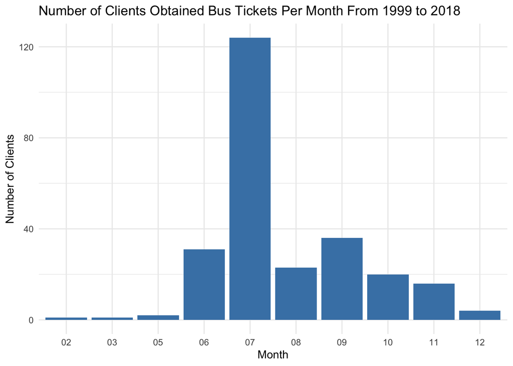

##### With combined data from 1999-2018, in the month July, that’s when clients most often request for bus tickets. Therefore, it is important to look deeper into the dataset to see whether the pattern actuallly exist, or if it exists for every year.

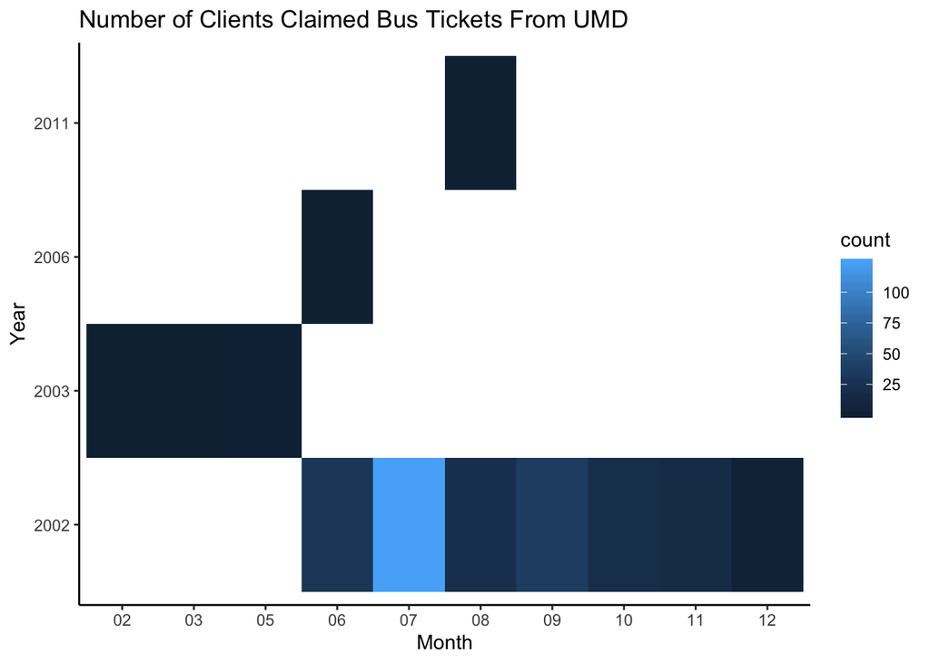

##### From this plot, we can see that the data suggest that bus service has not been in use since 2011. Even in earlier years, bus tickets were not requested that often. Even though it sees like the month july may be a popular month to request for bus tickets in 2002, it is more likely to be a coincident for that year.

## Relationship Between Hygiene Kits Services and the Month of the Year

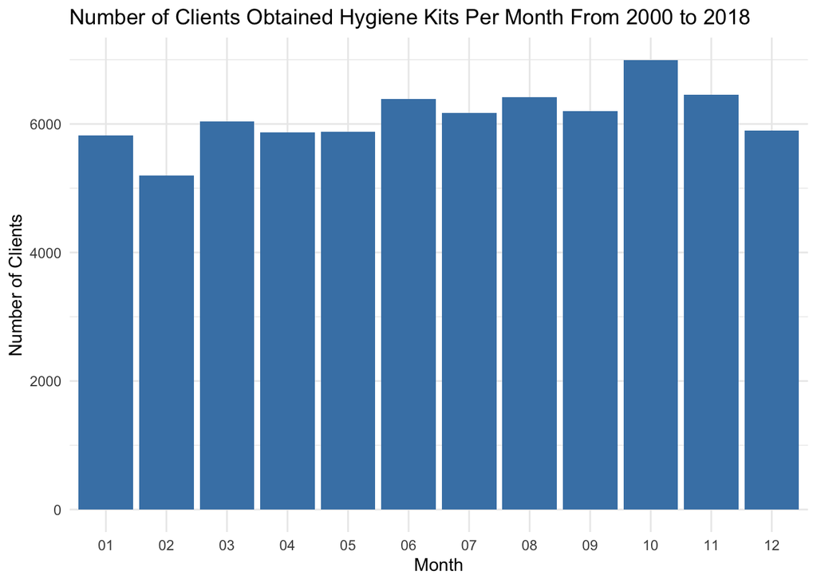

##### The plot suggests that in the last 20 years, approximately the same number of visitors obtained hygiene kits each month. There may not be any significant differences among the months.

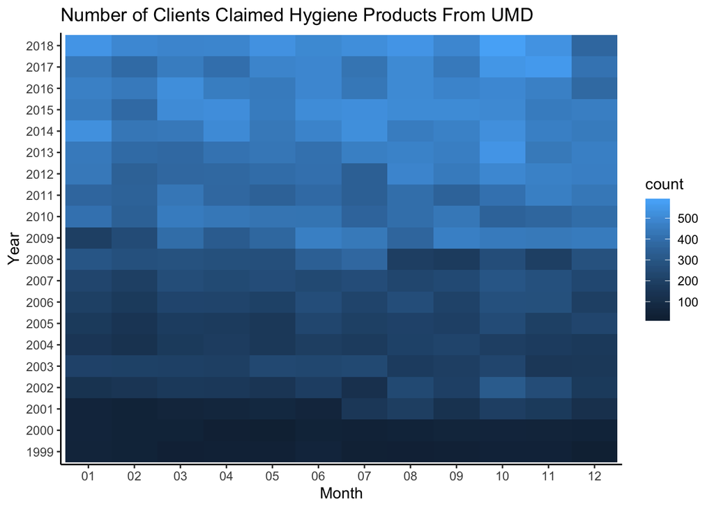

##### As one look across the plot, we can see that the shade of the color didn’t change very much, suggesting that the there may not exist any relationship between the number of clients for hygiene products and the month of the year. However, we can see that in general there exists an increasing number of clients requesting for hygiene products over the years.

## Relationship Between Food Product Services and the Month of the Year

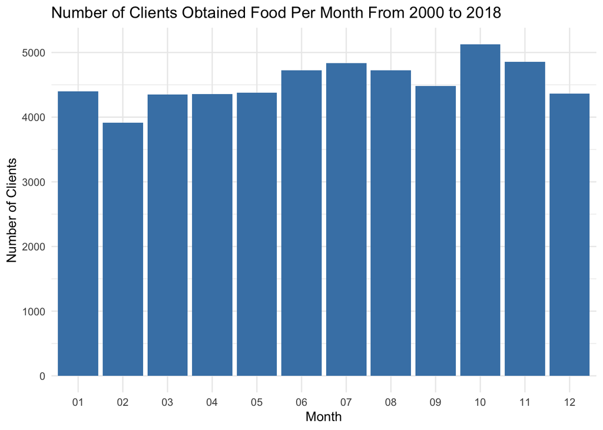

##### From this plot, we would claim that there does not exist a relationship between the month of the year and the number of clients since the numbers are relatively close. However, a deeper look is taken using heatmap.

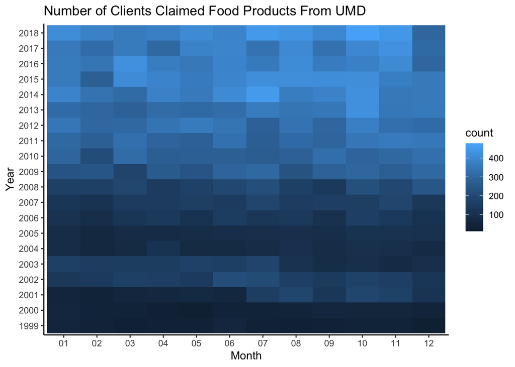

##### Similarly, there isn’t a decreasing in the color of the shade across the rows, thus we can conclude that there does not exist a relationship between the month and the number of clients who claimed food products from UMD. However, there has been an increasing number of clients request for food products in the past 20 years.

## Conclusion

##### There is an increasing number of clients within the last 20 years, thus UMD has been supporting more residents. UMD provides useful services since there are returners every year. Service that provides bus tickets has not been used since 2011. And there may not be any relationship between the month of the year and the services.